# Coronavirus US - USA Facts

davegoblue

2022-09-13

## Background

This module builds on code contained in Coronavirus_Statistics_USAF_v006.Rmd. This file includes the latest code for analyzing data from [USA Facts](https://usafacts.org/visualizations/coronavirus-covid-19-spread-map/). USA Facts maintains data on cases and deaths by county for coronavirus in the US. Downloaded data are unique by county with date as a column and a separate file for each of cases, deaths, and population.

The intent of this code is to source updated functions that allow for readRunUSAFacts() to be run to obtain, read, process, and analyze data from USA Facts.

## Sourcing Functions

The tidyverse library is loaded, and the functions used for CDC daily processing are sourced. Additionally, specific functions for USA Facts are also sourced:

```r
library(tidyverse)
# Functions are available in source file
source("./Generic_Added_Utility_Functions_202105_v001.R")
source("./Coronavirus_CDC_Daily_Functions_v002.R")
source("./Coronavirus_USAF_Functions_v001.R")
```

Further, the mapping file specific to USA Facts is sourced:

```r
source("./Coronavirus_USAF_Default_Mappings_v002.R")
```

Updated functions for diagnoseClusters(), createDetailedSummaries(), createSummary(), and helperSummaryMap() are included in Coronavirus_USAF_Functions_v001.R. These functions should be checked for consistency with state-level data with just a single copy kept later.

## Example Process

The latest county-level burden data are downloaded:

```
##
## No file has been downloaded, will use existing file: ./RInputFiles/Coronavirus/covid_confirmed_usafacts_downloaded_20220913.csv
```

```
##
## *** File has been checked for uniqueness by: countyFIPS countyName state stateFIPS
##
##
## *** File has been checked for uniqueness by: countyFIPS stateFIPS date
```

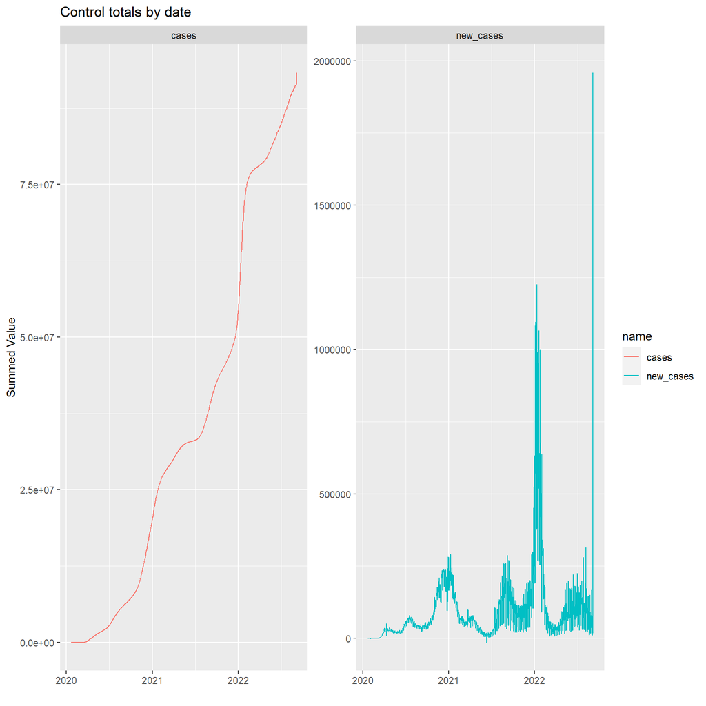

```
##
##
## Checking for similarity of: column names
## In reference but not in current:
## In current but not in reference:
##
## Checking for similarity of: date
## In reference but not in current: 0
## In current but not in reference: 33
## Detailed differences available in: ./RInputFiles/Coronavirus/USAF_NewData_20220913_chk_v005.log
##
## Checking for similarity of: county
## In reference but not in current:
## In current but not in reference:
```

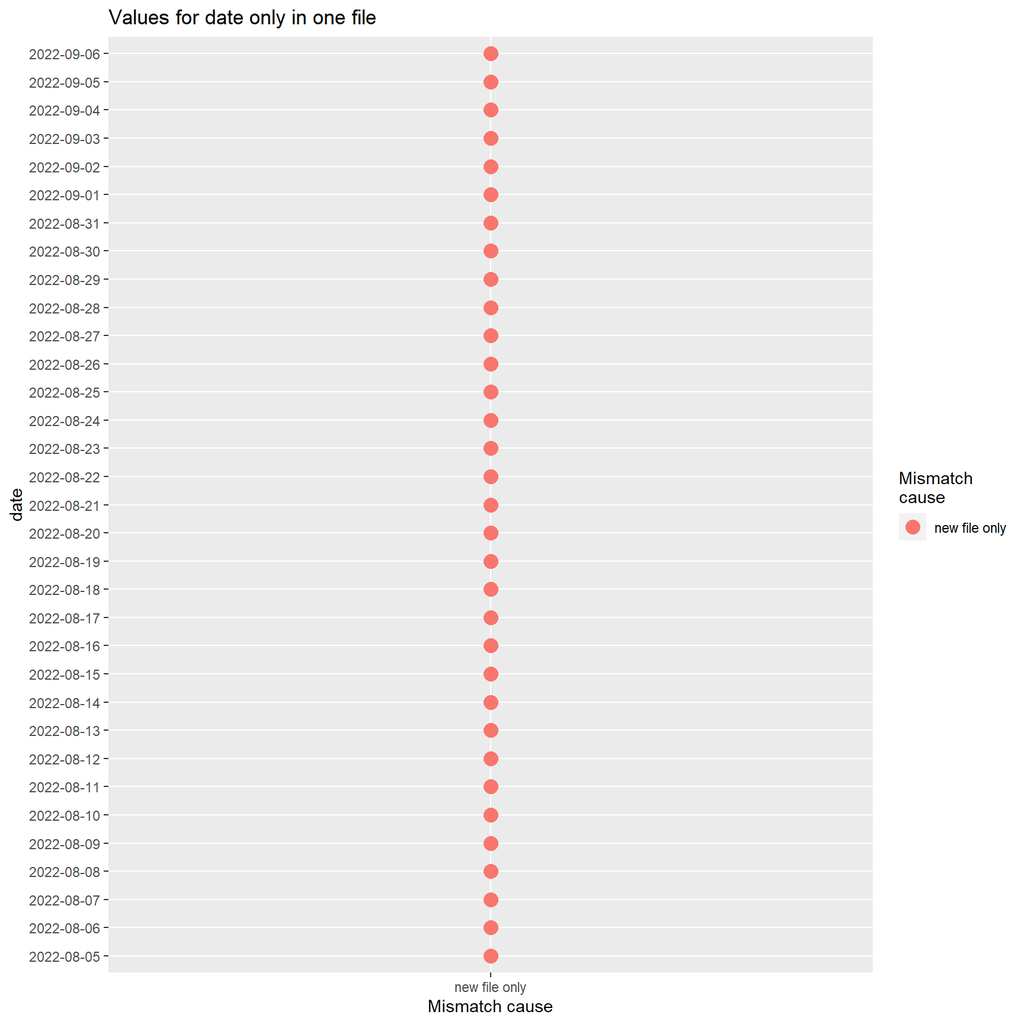

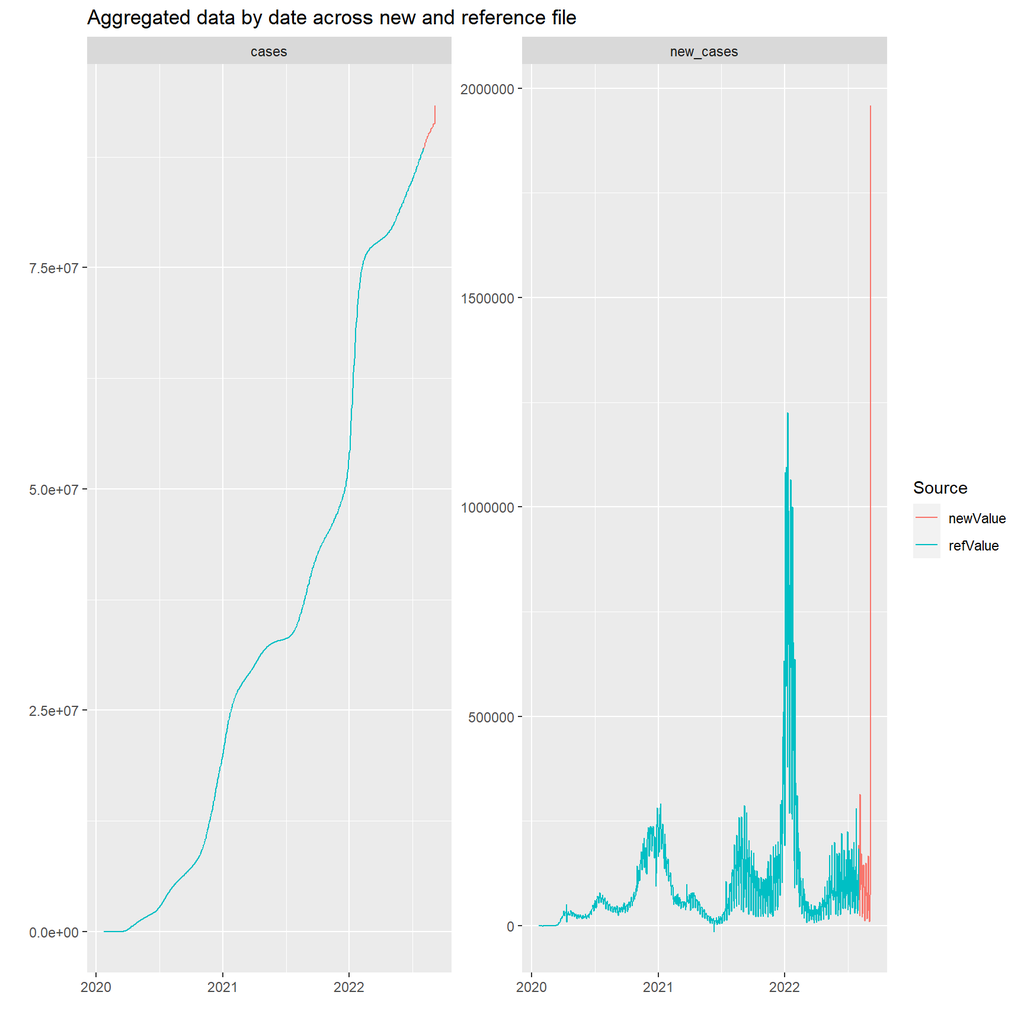

```
##
##
## ***Differences of at least 5 and at least 5%
##
## 2 records
## Detailed output available in log: ./RInputFiles/Coronavirus/USAF_NewData_20220913_chk_v005.log
```

```
##
##
## ***Differences of at least 0 and at least 0.1%
##
## 128 records
## Detailed output available in log: ./RInputFiles/Coronavirus/USAF_NewData_20220913_chk_v005.log
```

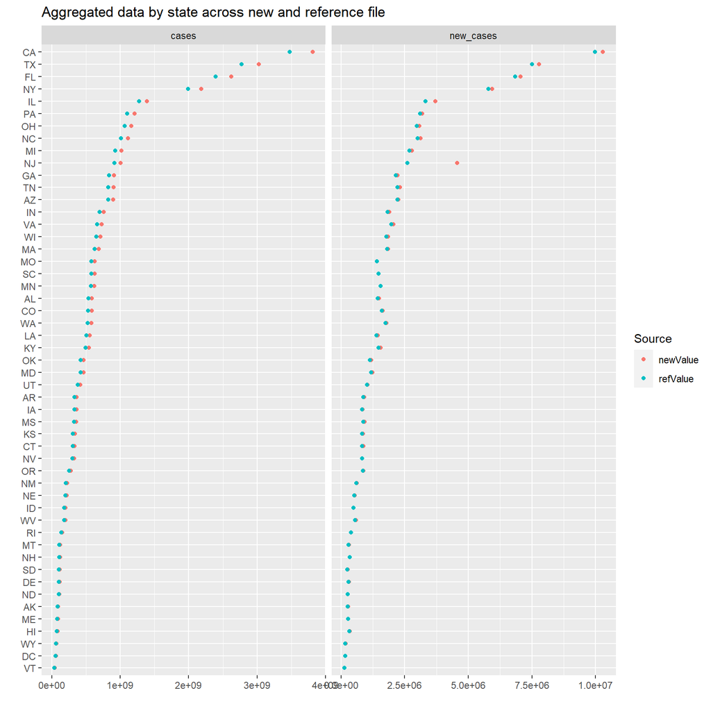

```
##
## *** File has been checked for uniqueness by: countyFIPS countyName state stateFIPS
##
##
## *** File has been checked for uniqueness by: countyFIPS stateFIPS date
```

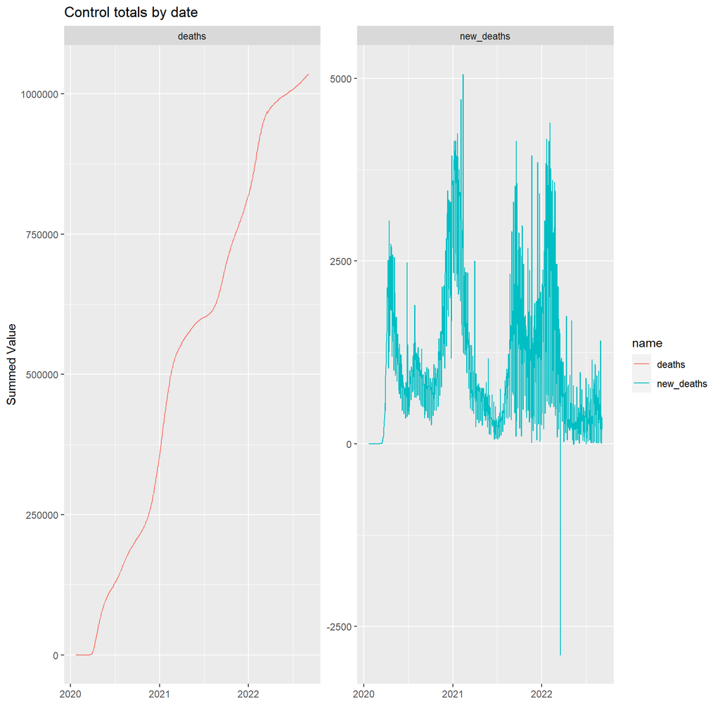

```
##
##
## Checking for similarity of: column names
## In reference but not in current:
## In current but not in reference:
##
## Checking for similarity of: date
## In reference but not in current: 0
## In current but not in reference: 33
## Detailed differences available in: ./RInputFiles/Coronavirus/USAF_NewData_20220913_chk_v005.log
##
## Checking for similarity of: county
## In reference but not in current:
## In current but not in reference:
```

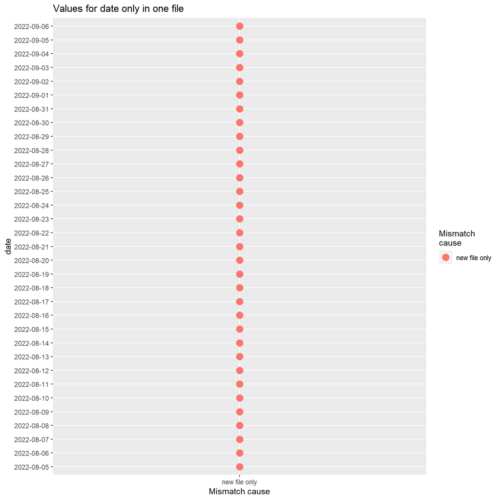

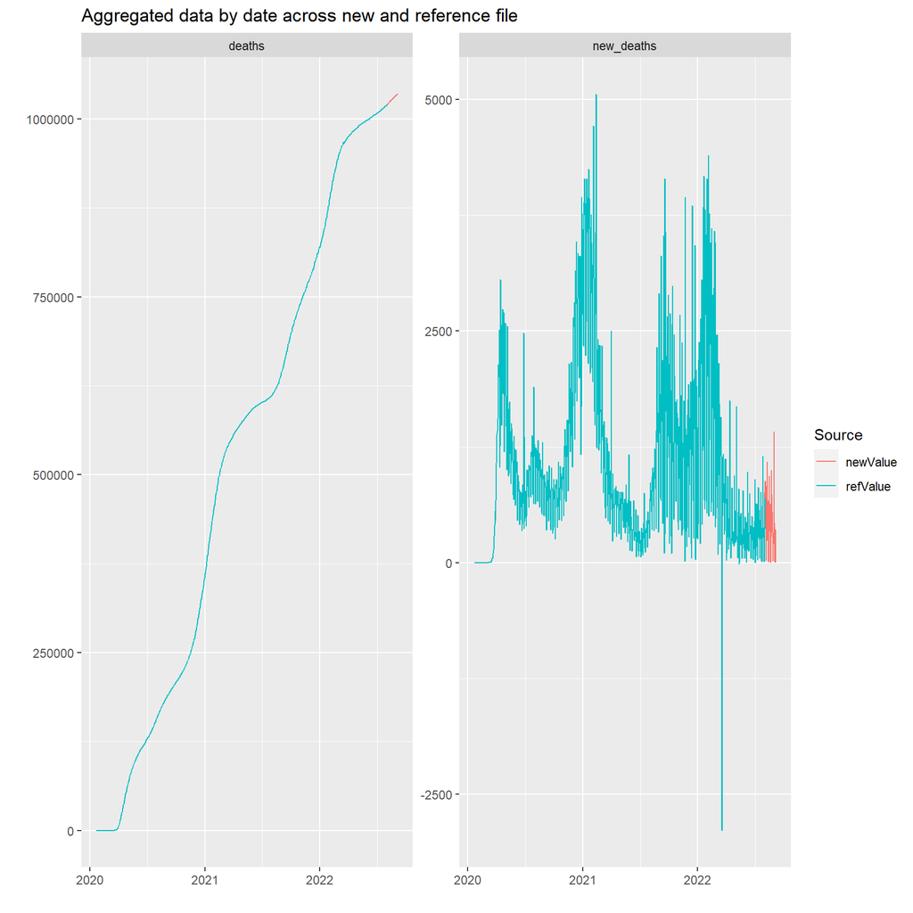

```
##
##
## ***Differences of at least 5 and at least 5%
##
## 3 records
## Detailed output available in log: ./RInputFiles/Coronavirus/USAF_NewData_20220913_chk_v005.log
```

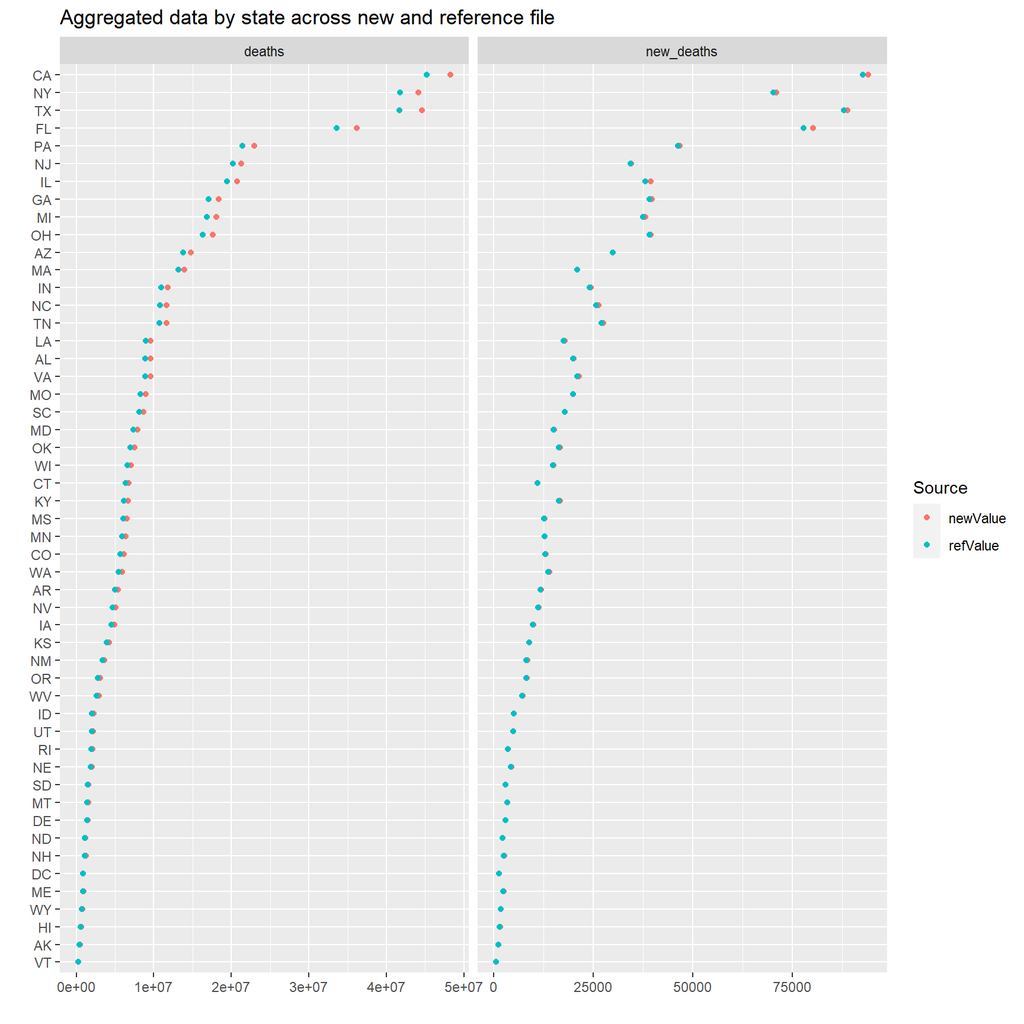

```
##
##
## ***Differences of at least 0 and at least 0.1%
##
## 108 records
## Detailed output available in log: ./RInputFiles/Coronavirus/USAF_NewData_20220913_chk_v005.log
##
##
## Column sums before and after applying filtering rules:
## # A tibble: 3 × 4
##   isType    cases     new_cases            n
##   <chr>     <dbl>         <dbl>        <dbl>
## 1 before 3.45e+10 93305986      3058894
## 2 after  3.43e+10 91158859      3010036
## 3 pctchg 7.16e- 3        0.0230       0.0160
##
##
## Column sums before and after applying filtering rules:
## # A tibble: 3 × 4
##   isType  deaths   new_deaths            n
##   <chr>    <dbl>        <dbl>        <dbl>
## 1 before 5.12e+8 1034939      3058894
## 2 after  4.95e+8  964043      3010036
## 3 pctchg 3.23e-2       0.0685       0.0160
```

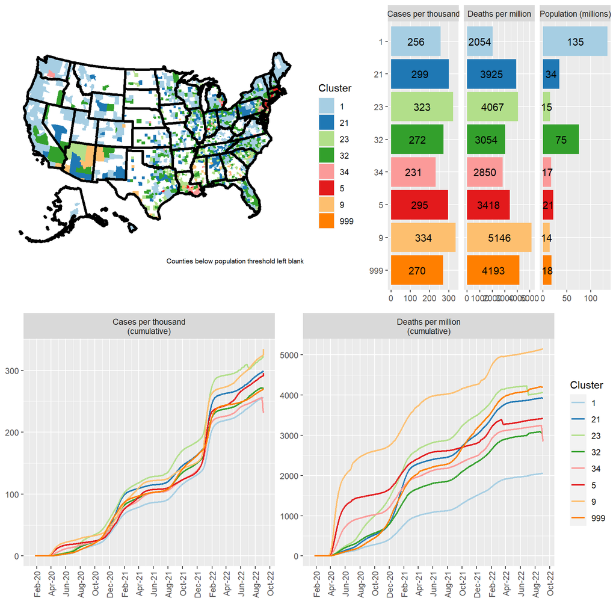

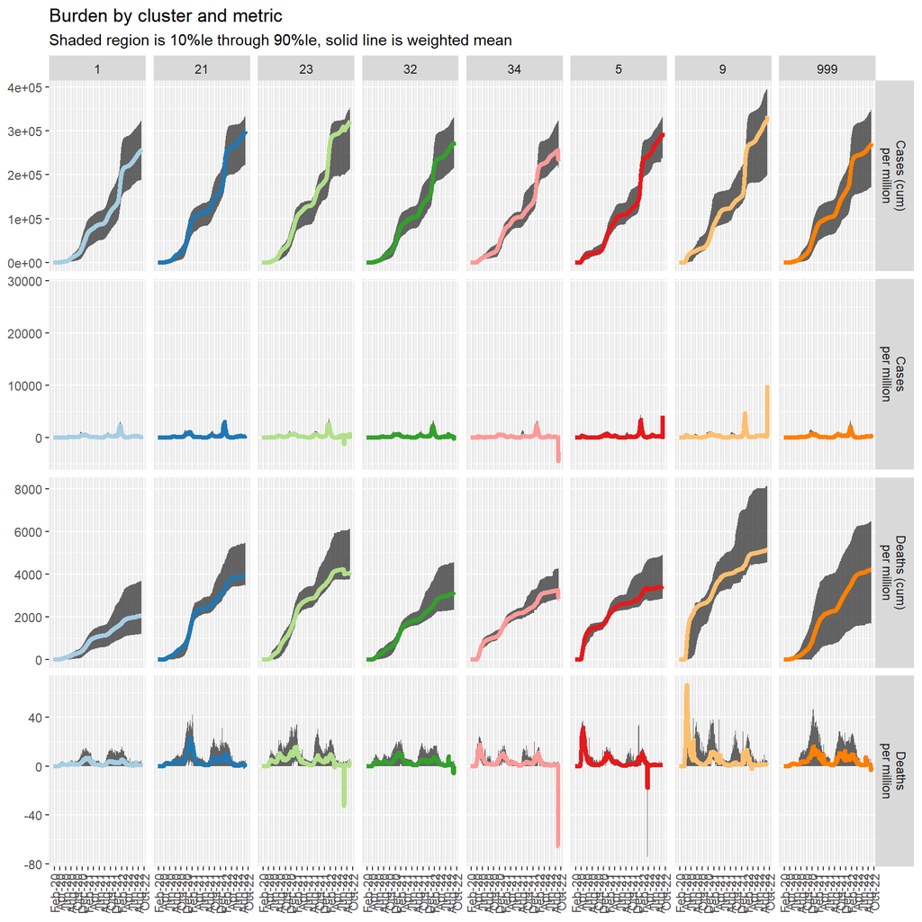

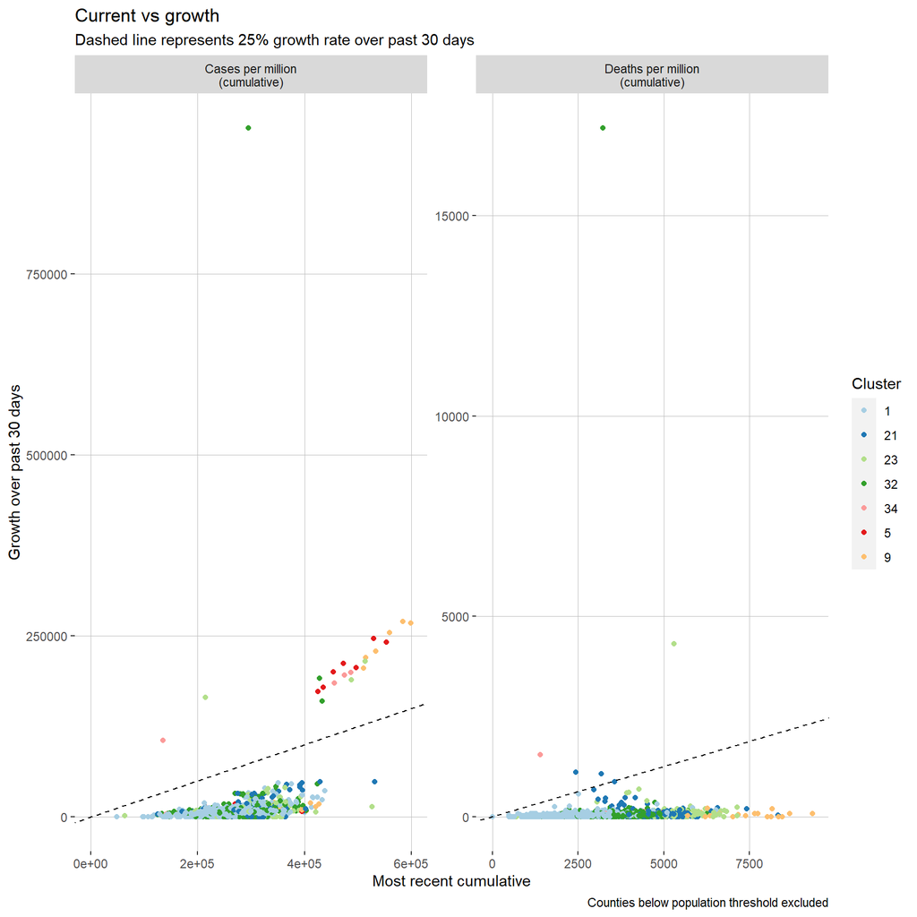

```r
readList <- list("usafCase"="./RInputFiles/Coronavirus/covid_confirmed_usafacts_downloaded_20220913.csv",
                 "usafDeath"="./RInputFiles/Coronavirus/covid_deaths_usafacts_downloaded_20220913.csv"
                 )
compareList <- list("usafCase"=readFromRDS("cty_newdata_20220807")$dfRaw$usafCase,
                    "usafDeath"=readFromRDS("cty_newdata_20220807")$dfRaw$usafDeath
                    )

# Use existing clusters
cty_newdata_20220913 <- readRunUSAFacts(maxDate="2022-09-11",
                                        downloadTo=lapply(readList,
                                                          FUN=function(x) if(file.exists(x)) NA else x
                                                          ),
                                        readFrom=readList,
                                        compareFile=compareList,
                                        writeLog="./RInputFiles/Coronavirus/USAF_NewData_20220913_chk_v005.log",
                                        ovrwriteLog=TRUE,
                                        useClusters=readFromRDS("cty_newdata_20210813")$useClusters,
                                        skipAssessmentPlots=FALSE,
                                        brewPalette="Paired"
                                        )
```

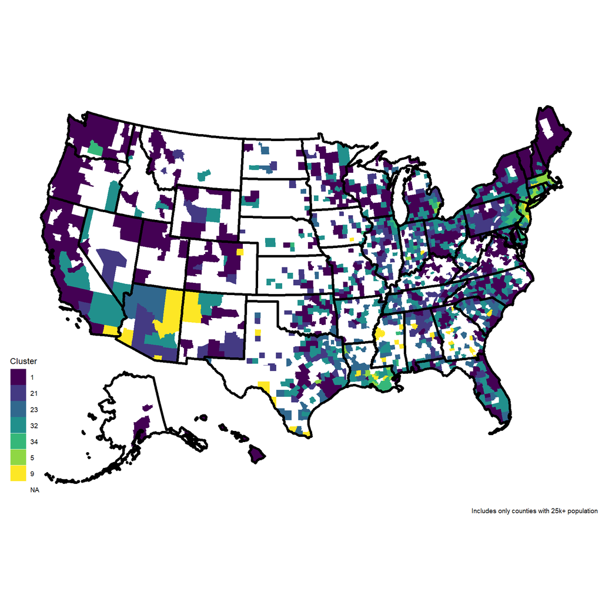

```r
# Plot all counties based on closest cluster
sparseCountyClusterMap(cty_newdata_20220913$useClusters,
                       caption="Includes only counties with 25k+ population",
                       brewPalette="viridis"
                       )
```

```r
# Save the refreshed file
saveToRDS(cty_newdata_20220913, ovrWriteError=FALSE)
```

Vaccines data are also updated, though the process needs to integrate previous data:

```r
cty_vaxdata_20220914 <- processCountyVaccines(loc="./RInputFiles/Coronavirus/county_vaccine_20220914.csv",
                                              ctyList=cty_newdata_20220913,
                                              minDateCD=c("2022-06-09", "2022-06-09"),
                                              maxDateCD="2022-09-01"
                                              )
```

```
##
## Records from other than 50 states and DC:
## # A tibble: 9 × 2
##   state     n
##   <chr> <int>
## 1 AS       24
## 2 FM       25
## 3 GU       48
## 4 MH       24
## 5 MP       24
## 6 PR     1901
## 7 PW       24
## 8 VI       96
## 9 <NA>     17
```

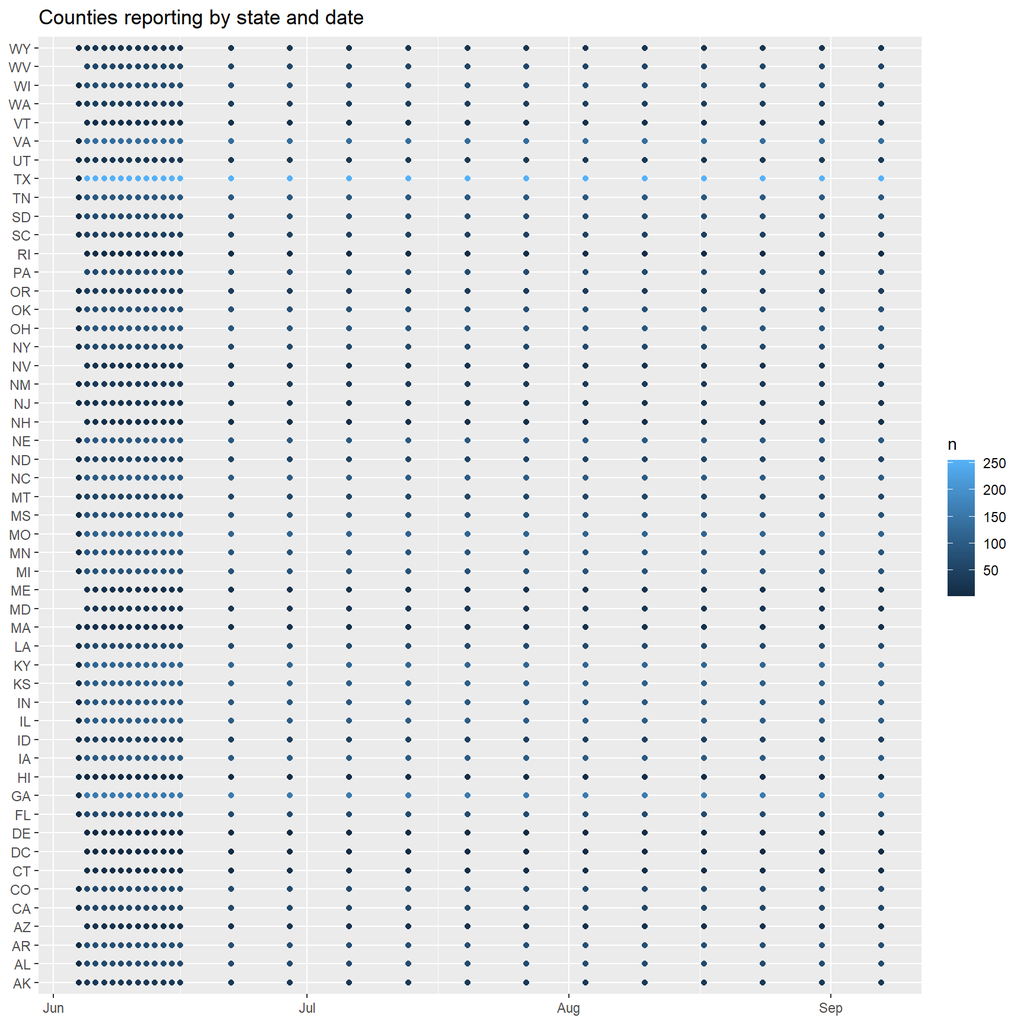

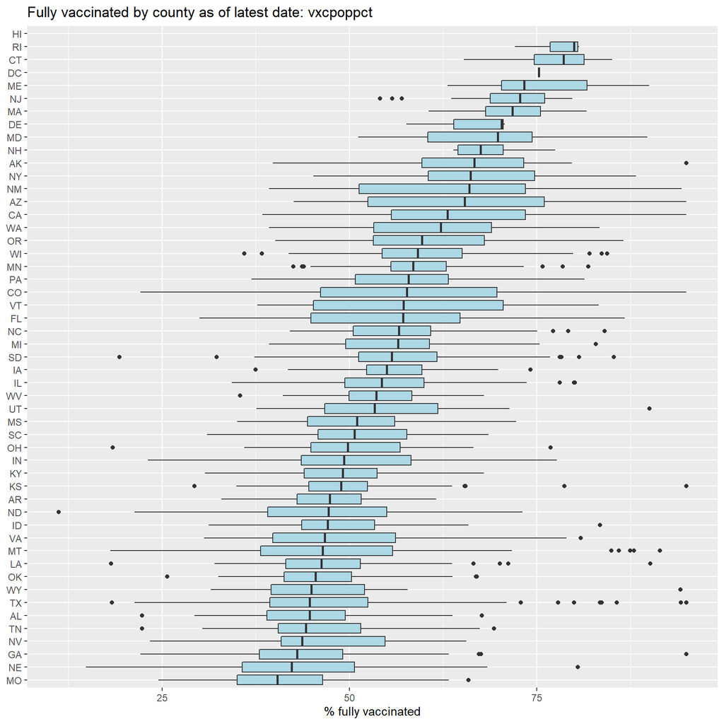

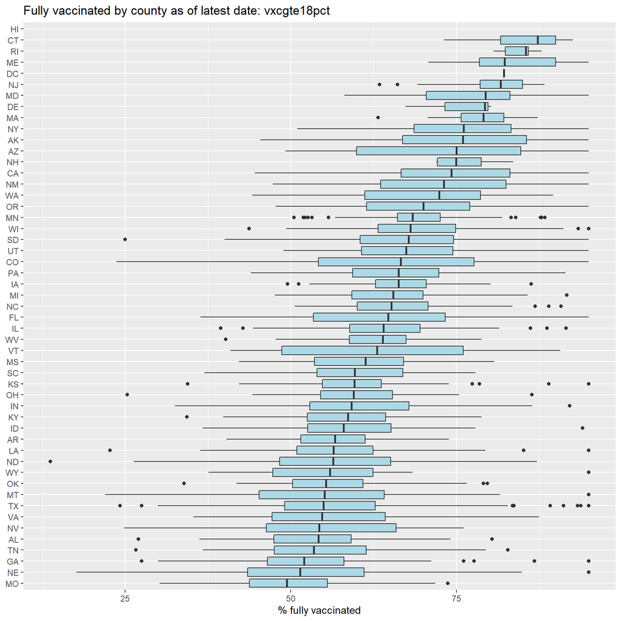

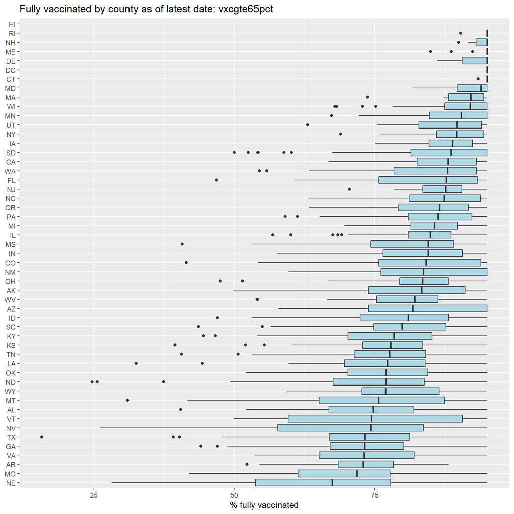

```
##
## Count of NA records by column
##           state            FIPS popgte65_minpop popgte65_maxpop    popgte65_nnA
##               0               0               0               0               0
##               n
##               0
##
## Records where minimum and maximum population differ# A tibble: 0 × 5
## # … with 5 variables: state <chr>, FIPS <chr>, age <chr>, minpop <dbl>,
## #   maxpop <dbl>
## # ℹ Use `colnames()` to see all variable names
##
##
##
## Will run with parameters:
## burdenVar: cpm dpm
## vaxVar: vxcpoppct vxcpoppct
## minDateCD: 2022-06-09 2022-06-09
## maxDateCD: 2022-09-01 2022-09-01
```

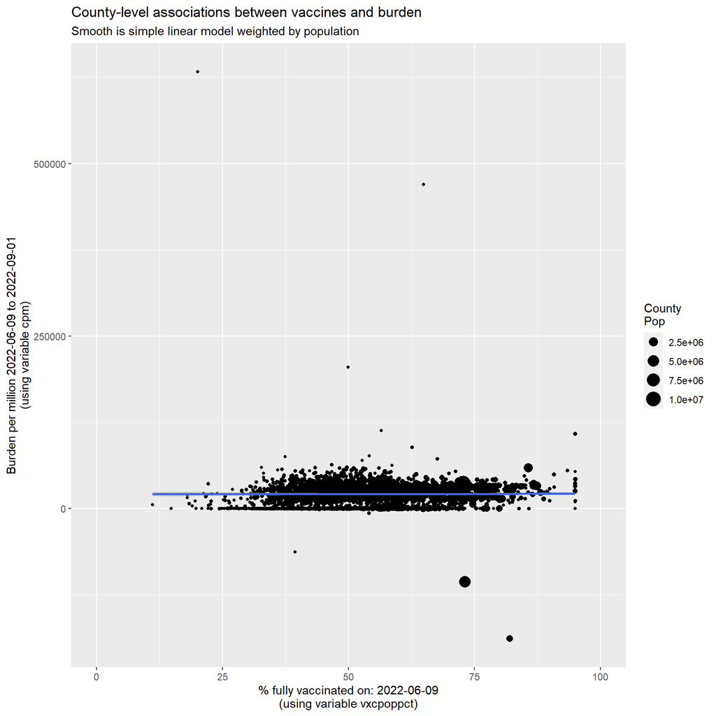

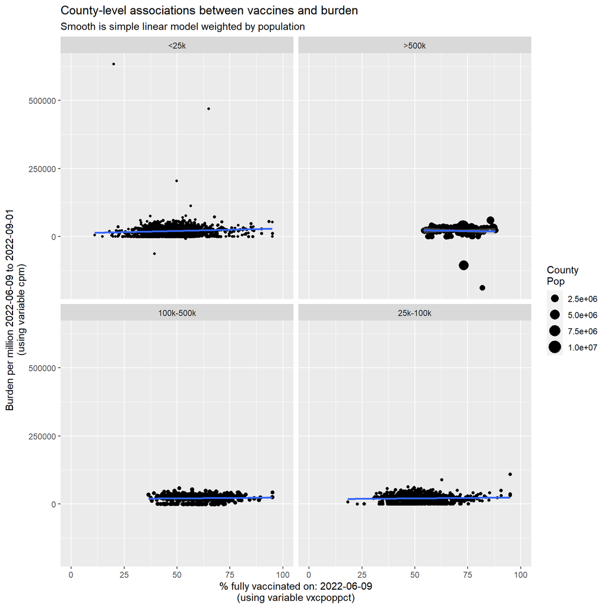

```
##
## Call:
## lm(formula = get(burdenVar) ~ vaxMetric, data = dfReg, weights = pop)
##
## Weighted Residuals:
##        Min         1Q     Median         3Q        Max
## -289154037   -1505413     -90865    1548407   62031339
##
## Coefficients:
##              Estimate Std. Error t value Pr(>|t|)
## (Intercept) 20807.226   2187.230   9.513   <2e-16 ***
## vaxMetric       8.061     33.809   0.238    0.812
## ---
## Signif. codes:  0 '***' 0.001 '**' 0.01 '*' 0.05 '.' 0.1 ' ' 1
##
## Residual standard error: 7367000 on 3124 degrees of freedom
##   (16 observations deleted due to missingness)
## Multiple R-squared:  1.82e-05,   Adjusted R-squared:  -0.0003019
## F-statistic: 0.05684 on 1 and 3124 DF,  p-value: 0.8116
##
##
## Call:
## lm(formula = get(burdenVar) ~ vaxMetric * type + 0 - vaxMetric,
##     data = dfReg, weights = pop)
##
## Weighted Residuals:
##        Min         1Q     Median         3Q        Max
## -288389946   -1463009     -64586    1597997   65055859
##
## Coefficients:
##                         Estimate Std. Error t value Pr(>|t|)
## type<25k                12176.47    7942.37   1.533 0.125352
## type>500k               29162.62    4682.01   6.229 5.34e-10 ***
## type100k-500k           17769.84    4666.92   3.808 0.000143 ***
## type25k-100k            17521.42    5263.39   3.329 0.000882 ***
## vaxMetric:type<25k        175.75     159.92   1.099 0.271861
## vaxMetric:type>500k      -110.85      66.36  -1.670 0.094933 .
## vaxMetric:type100k-500k    60.38      74.96   0.805 0.420630
## vaxMetric:type25k-100k     66.14      99.33   0.666 0.505574
## ---
## Signif. codes:  0 '***' 0.001 '**' 0.01 '*' 0.05 '.' 0.1 ' ' 1
##
## Residual standard error: 7368000 on 3118 degrees of freedom
##   (16 observations deleted due to missingness)
## Multiple R-squared:  0.4677, Adjusted R-squared:  0.4663
## F-statistic: 342.4 on 8 and 3118 DF,  p-value: < 2.2e-16
```

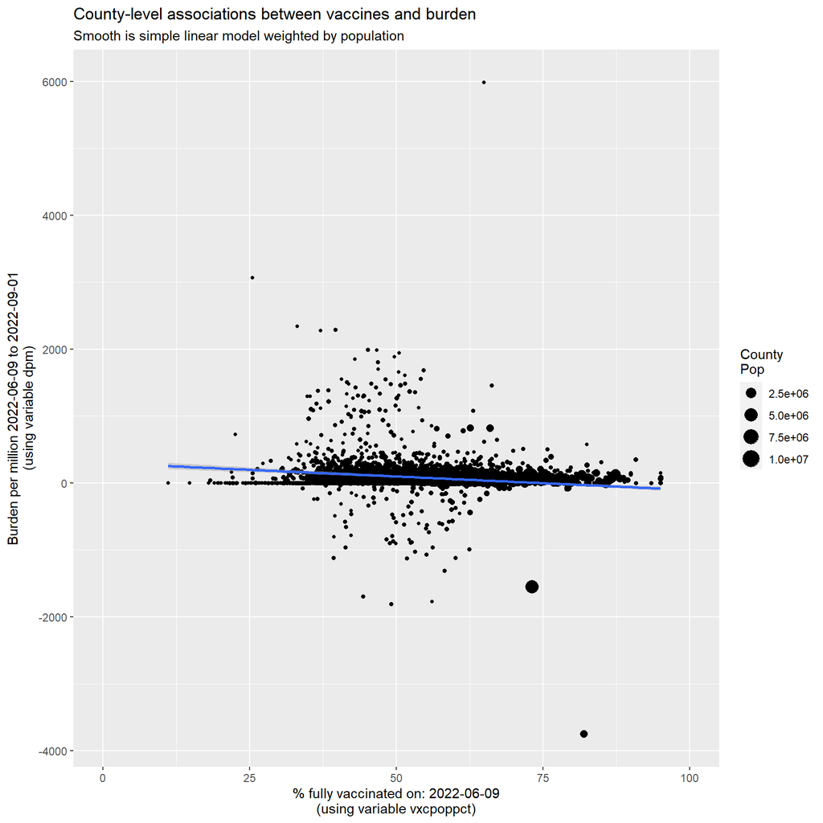

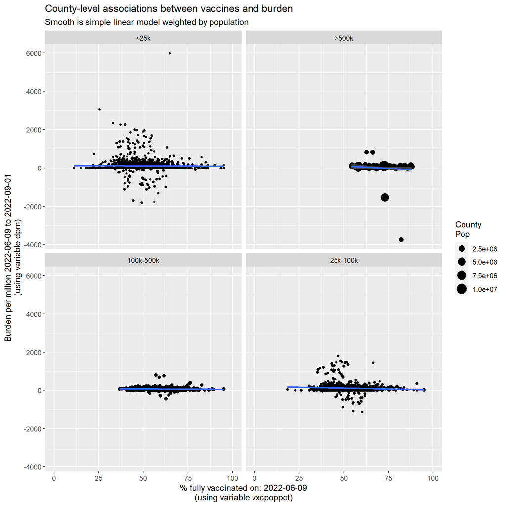

```
##
## Call:
## lm(formula = get(burdenVar) ~ vaxMetric, data = dfReg, weights = pop)
##
## Weighted Residuals:
##      Min       1Q   Median       3Q      Max
## -3529509   -12224    -2495    14425   697276
##
## Coefficients:
##             Estimate Std. Error t value Pr(>|t|)
## (Intercept) 298.9805    29.5946  10.103   <2e-16 ***
## vaxMetric    -4.0106     0.4575  -8.767   <2e-16 ***
## ---
## Signif. codes:  0 '***' 0.001 '**' 0.01 '*' 0.05 '.' 0.1 ' ' 1
##
## Residual standard error: 99680 on 3124 degrees of freedom
##   (16 observations deleted due to missingness)
## Multiple R-squared:  0.02401,    Adjusted R-squared:  0.0237
## F-statistic: 76.86 on 1 and 3124 DF,  p-value: < 2.2e-16
##
##
## Call:
## lm(formula = get(burdenVar) ~ vaxMetric * type + 0 - vaxMetric,
##     data = dfReg, weights = pop)
##
## Weighted Residuals:
##      Min       1Q   Median       3Q      Max
## -3480323   -13174    -5106    10332   707402
##
## Coefficients:
##                         Estimate Std. Error t value Pr(>|t|)
## type<25k                130.2314   107.0422   1.217  0.22384
## type>500k               383.7067    63.1011   6.081 1.34e-09 ***
## type100k-500k            99.6779    62.8978   1.585  0.11312
## type25k-100k            207.0272    70.9366   2.918  0.00354 **
## vaxMetric:type<25k       -0.3702     2.1553  -0.172  0.86365
## vaxMetric:type>500k      -5.4661     0.8943  -6.112 1.11e-09 ***
## vaxMetric:type100k-500k  -0.5040     1.0103  -0.499  0.61791
## vaxMetric:type25k-100k   -1.8241     1.3388  -1.362  0.17314
## ---
## Signif. codes:  0 '***' 0.001 '**' 0.01 '*' 0.05 '.' 0.1 ' ' 1
##
## Residual standard error: 99300 on 3118 degrees of freedom
##   (16 observations deleted due to missingness)
## Multiple R-squared:  0.05224,    Adjusted R-squared:  0.04981
## F-statistic: 21.48 on 8 and 3118 DF,  p-value: < 2.2e-16
```

```r
# Save the refreshed file
saveToRDS(cty_vaxdata_20220914, ovrWriteError=FALSE)
```

County-level data are post-processed:

```r
cty_postdata_20220913 <- postProcessCountyData(lstCtyBurden=cty_newdata_20220913$dfPerCapita,
                                               lstCtyVax=cty_vaxdata_20220914$vaxFix,
                                               lstState=readFromRDS("cdc_daily_220902")$dfPerCapita
                                               )
```

```
##
## Parameter maxDate is: 2022-09-01
```

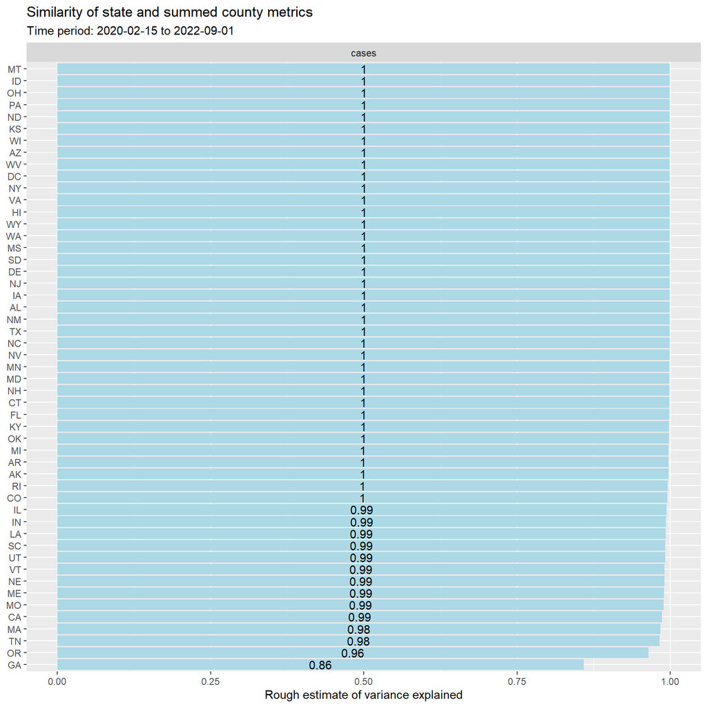

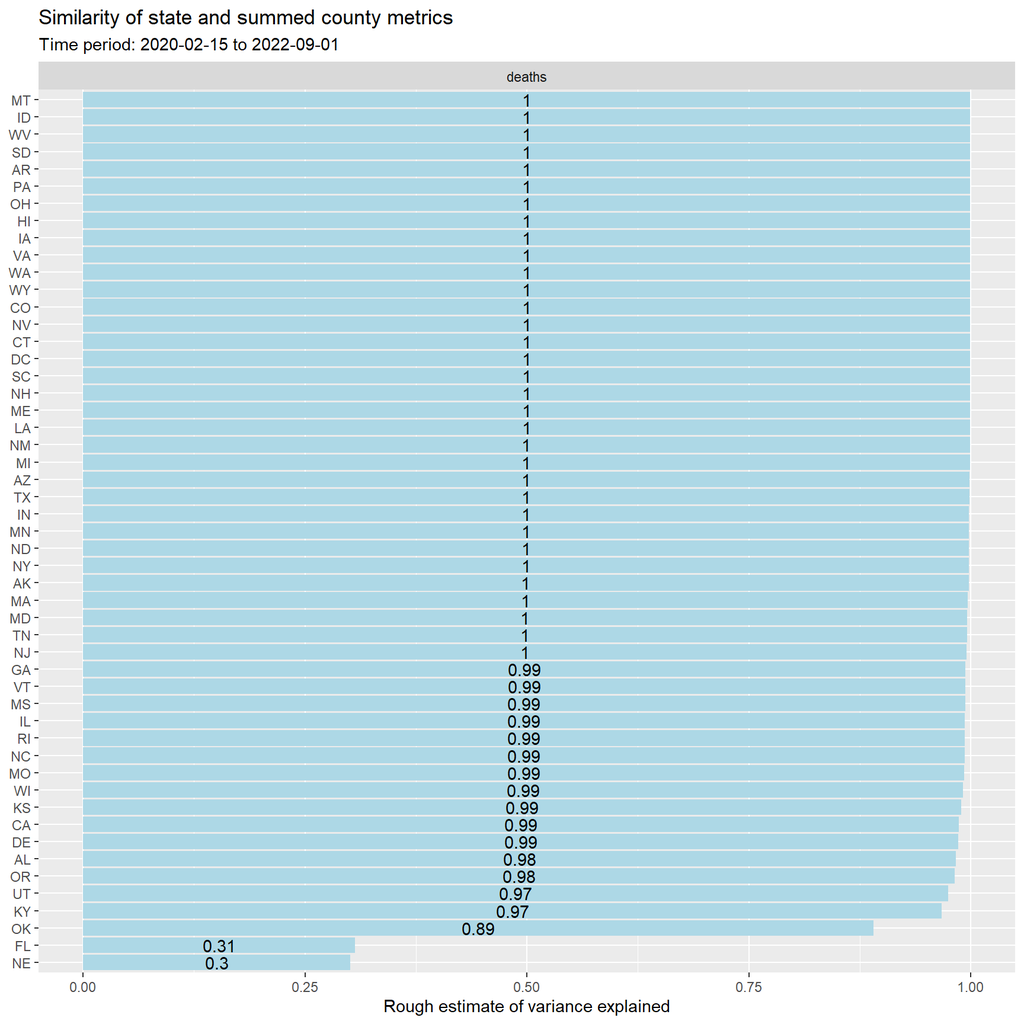

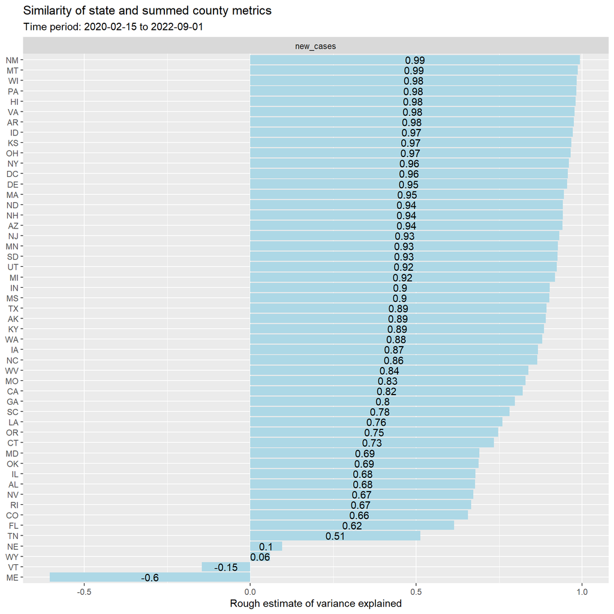

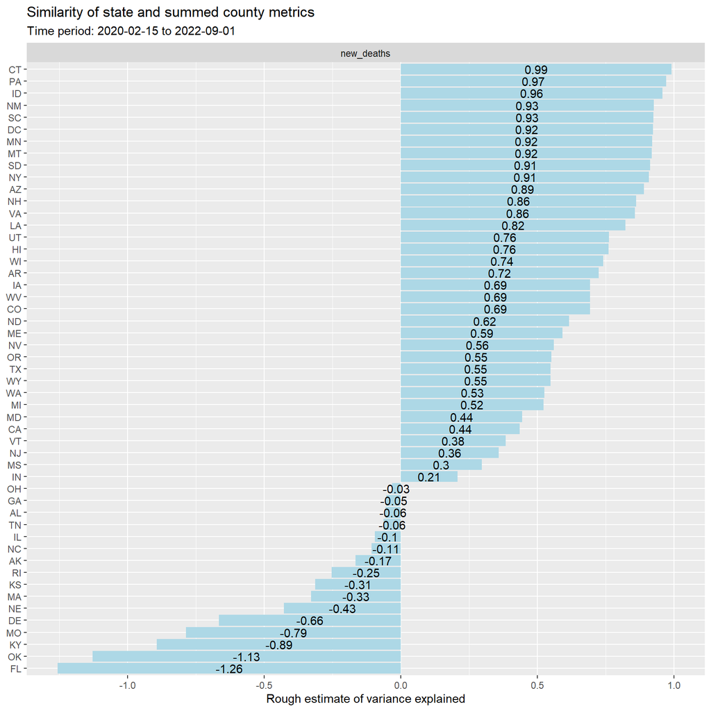

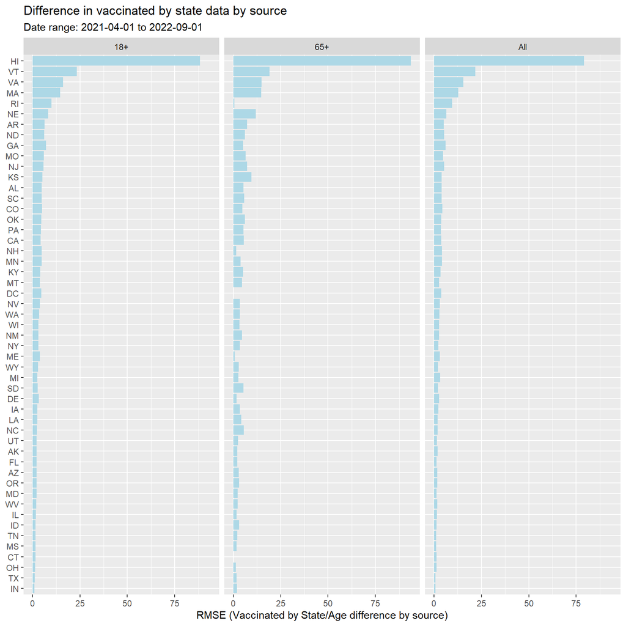

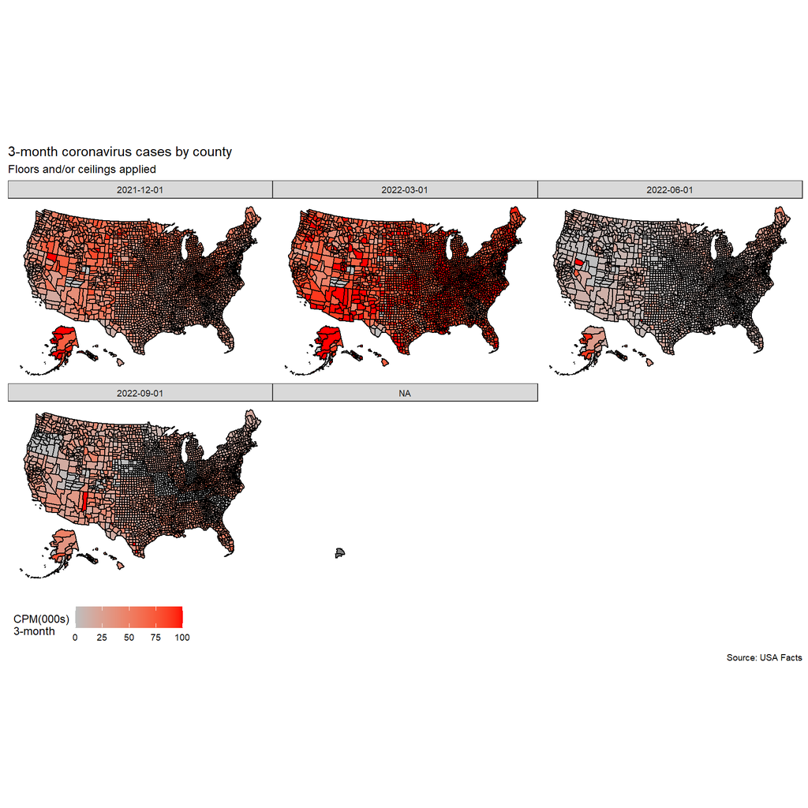

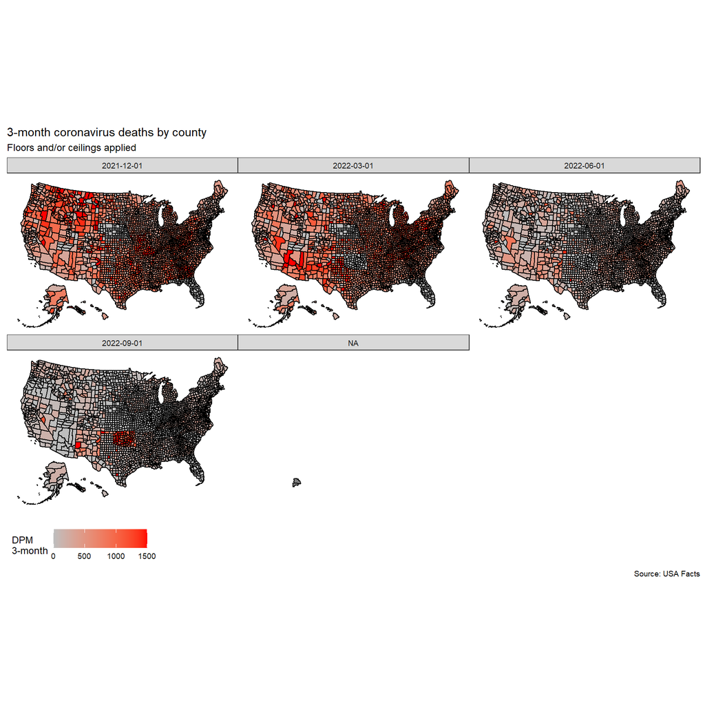

```r
# Save the refreshed file
saveToRDS(cty_postdata_20220913, ovrWriteError=FALSE)
```

Additional post-processing steps are run:

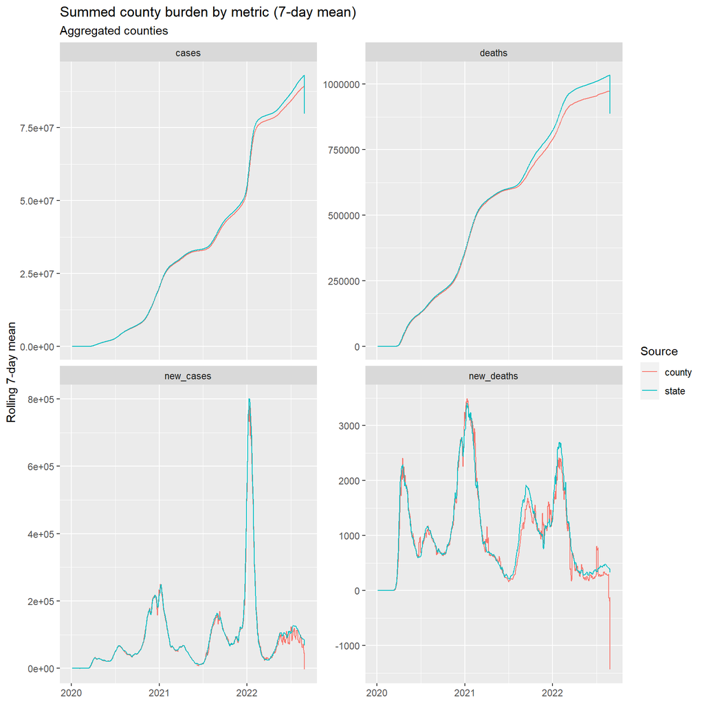

```r
# Step 1a: Burden comparisons for aggregated states
additionalCountyPostProcess(cty_postdata_20220913, p1CompareStates=c(state.abb, "DC"), p1AggData=TRUE)
```